## 1. Conociendo los datos

```r
# 1.1 installa and load tidyverse.
# install.packages('tidyverse')
library(tidyverse)
# 1.2 read csv
setwd("~/MASTER/funadmetos de progrmacion/PROYECTO/Proyecto_r")
yearly <- read.csv('deaths_handwashing.csv')
# 1.3 print yearly
yearly
```

```
##    year births deaths   clinic
## 1  1841   3036    237 clinic 1
## 2  1842   3287    518 clinic 1
## 3  1843   3060    274 clinic 1
## 4  1844   3157    260 clinic 1
## 5  1845   3492    241 clinic 1
## 6  1846   4010    459 clinic 1
## 7  1841   2442     86 clinic 2
## 8  1842   2659    202 clinic 2
## 9  1843   2739    164 clinic 2
## 10 1844   2956     68 clinic 2
## 11 1845   3241     66 clinic 2
## 12 1846   3754    105 clinic 2
```

## 2. El alarmante número de muertes

```r
# 2.1 calculate proportion_deaths
yearly<- yearly %>%
  mutate(proportion_deaths = deaths/births)
# 2.2 print yearly
yearly
```

```
##    year births deaths   clinic proportion_deaths
## 1  1841   3036    237 clinic 1        0.07806324
## 2  1842   3287    518 clinic 1        0.15759051
## 3  1843   3060    274 clinic 1        0.08954248
## 4  1844   3157    260 clinic 1        0.08235667
## 5  1845   3492    241 clinic 1        0.06901489
## 6  1846   4010    459 clinic 1        0.11446384
## 7  1841   2442     86 clinic 2        0.03521704
## 8  1842   2659    202 clinic 2        0.07596841
## 9  1843   2739    164 clinic 2        0.05987587
## 10 1844   2956     68 clinic 2        0.02300406
## 11 1845   3241     66 clinic 2        0.02036409
## 12 1846   3754    105 clinic 2        0.02797017
```

## 3. Muerte en las clínicas

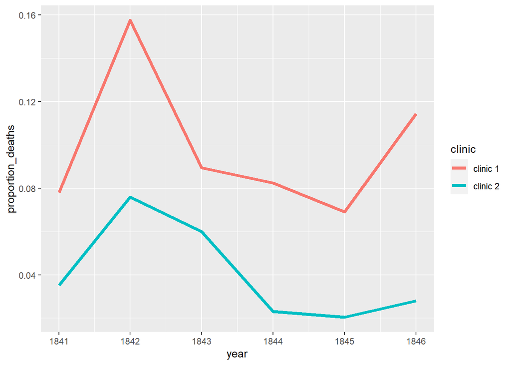

```r
# 3.1. Utilice ggplot para hacer una gráfica lineal de proportion_deaths por año (columna year) con una línea por clínica.
# 3.2. Las líneas deben tener colores distintos.
ggplot(yearly,aes(x=year, y =proportion_deaths,group=clinic,color=clinic))+geom_line(size=1.5)
```

## 4. Comienza el lavado de manos ##

¿Por qué la proporción de muertes es mucho más alta en la Clínica 1? La única diferencia en ambas clínicas era que muchos estudiantes de medicina trabajaban en la Clínica 1, mientras que en la Clínica 2 no había tantos. Otro dato interesante es que los médicos que atendían partos solo se encargaban de esa función, mientras que los estudiantes también pasaban tiempo en las salas de autopsias examinando cadáveres. Se empezó a sospechar que algo en los cadáveres, propagado de las manos de los estudiantes de medicina, causaba la enfermedad. Entonces, en un intento desesperado por detener las altas tasas de mortalidad, se decretó: ¡Lávese las manos en todo momento!

```r
# 4.1. Cargue los datos mensuales de la Clínica 1 para ver si el lavado de manos tuvo algún efecto, para esto lea el archivo deaths_clinic_1.csv y asígnelo a la variable monthly.
monthly <- read.csv('deaths_clinic_1.csv')
# 4.2. Agregue la columna proportion_deaths a monthly, esta nueva columna se calculará como la proporción de muertes por número de nacimientos.
monthly<- monthly %>%
  mutate(proportion_deaths = deaths/births)
# 4.3. Imprima las primeras filas de monthly usando la función head().
head(monthly)
```

```
##         date births deaths proportion_deaths
## 1 1841-01-01    254     37       0.145669291
## 2 1841-02-01    239     18       0.075313808
## 3 1841-03-01    277     12       0.043321300
## 4 1841-04-01    255      4       0.015686275
## 5 1841-05-01    255      2       0.007843137
## 6 1841-06-01    200     10       0.050000000
```

## 5. El efecto del lavado de manos

Con los datos cargados, ahora podemos ver la proporción de muertes a lo largo del tiempo.

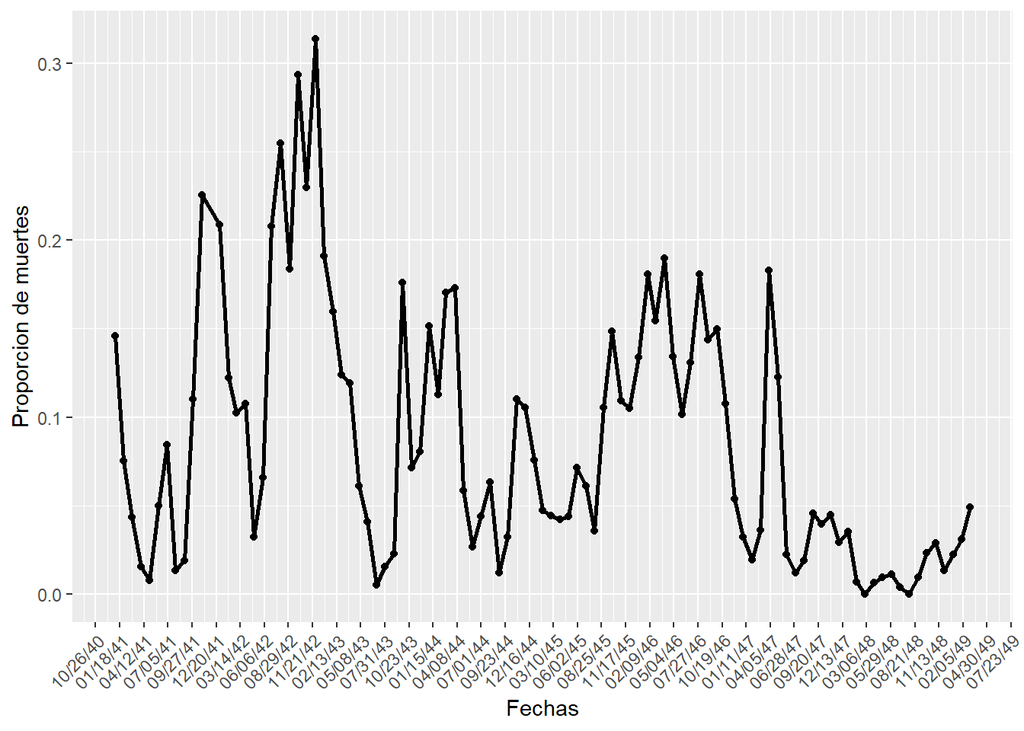

```r
# 5.1. Haga una gráfica lineal de proportion_deaths por fecha para el data frame monthly usando ggplot.
# 5.2. Utilice la función labs para dar al eje x y al eje y una estética a las etiquetas.
# fix date format for enhanced look of the graph
monthly$date <- as.Date(monthly$date)
ggplot(monthly,aes(x=date, y =proportion_deaths, group=1))+geom_point()+geom_line(size=1)+
 scale_x_date(date_breaks = "12 week", date_labels = "%D")+
 guides(x = guide_axis(angle = 45))+
 labs(x = "Fechas",y= "Proporcion de muertes" )
```

```r
# 5.3. Use group_by y summarise para encontrar la media por año y guárdelo en el dataset death_by_year.
death_by_year <- monthly %>%
  mutate(year =format(monthly$date,"%Y")) %>%
  group_by(year) %>%
  summarise(mean_by_year = mean(deaths))
death_by_year
```

```
## # A tibble: 9 × 2
##   year  mean_by_year
##   <chr>        <dbl>
## 1 1841         16.8
## 2 1842         43.4
## 3 1843         22.8
## 4 1844         21.7
## 5 1845         20.1
## 6 1846         38.2
## 7 1847         14.7
## 8 1848          3.75
## 9 1849         13.7
```

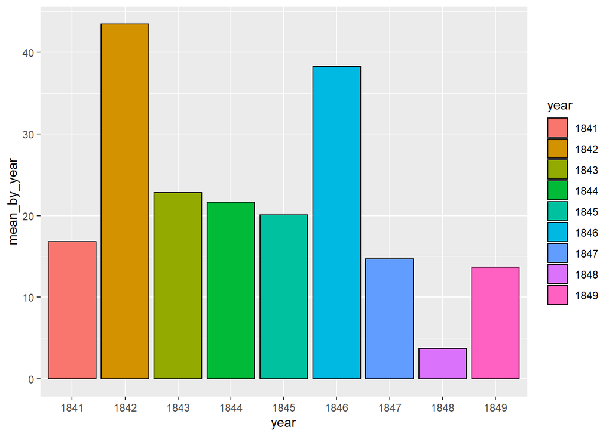

```r
# 5.4. Utilice el conjunto de datos death_by_year para crear un gráfico de barras que muestre la media en cada año.

ggplot(death_by_year,aes(x=year, y =mean_by_year, fill=year))+geom_col(colour = "black")
```

## 6. Los resultados del lavado de manos A partir del año 1847 la proporción de muertes se reduce drásticamente y, sí, fue entonces cuando se hizo obligatorio el lavado de manos. El efecto del lavado de manos se hace aún más claro si lo resaltamos en el gráfico.

```r
# 6.1. Agregue una columna TRUE/FALSE a monthly llamado handwashing_started, que será TRUE a partir del año en que se impuso el lavado de manos
monthly<- monthly %>%
  mutate(year =format(monthly$date,"%Y")) %>%
  mutate(handwashing_started= if_else(.$year >= 1847, TRUE, FALSE))
head(monthly)
```

```
##         date births deaths proportion_deaths year handwashing_started
## 1 1841-01-01    254     37       0.145669291 1841               FALSE
## 2 1841-02-01    239     18       0.075313808 1841               FALSE
## 3 1841-03-01    277     12       0.043321300 1841               FALSE
## 4 1841-04-01    255      4       0.015686275 1841               FALSE
## 5 1841-05-01    255      2       0.007843137 1841               FALSE
## 6 1841-06-01    200     10       0.050000000 1841               FALSE
```

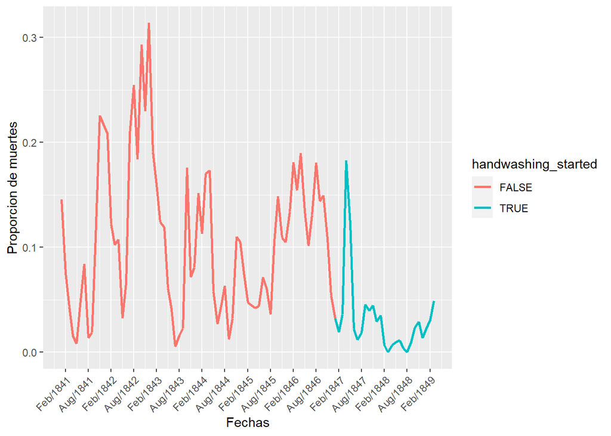

```r
#  6.2. Haga una gráfica lineal de proportion_deaths por fecha para el data frame monthly usando ggplot. Haga que el color de la línea dependa de handwashing_started.
#  6.3. Utilice la función labs para dar al eje x y al eje y una estética a las etiquetas.

ggplot(monthly,aes(x=date, y =proportion_deaths, group=1, color=handwashing_started))+geom_line(size=1) +
 scale_x_date(date_breaks = "6 month ", date_labels = "%b/%Y")+
 guides(x = guide_axis(angle = 45))+
 labs(x = "Fechas",y= "Proporcion de muertes" )
```

## 7. ¿Más lavado de manos, menos muertes? Nuevamente, las estadísticas demuestran que lavarse las manos tuvo un efecto enorme. ¿Cuánto redujo la proporción mensual de muertes en promedio?

```r
# 7.1. Utilice group_by y summarise para calcular el promedio de proportion_deaths antes y después de que se impusiera el lavado de manos.
# 7.2. Asigne el resultado en la variable month_summary e imprímala.
# 7.3. El data frame resultante debería verse como el siguiente:
month_summary <- monthly %>%
  group_by(handwashing_started) %>%
  summarise(proportion_deaths= mean(proportion_deaths)) %>%
  arrange(desc(handwashing_started))
month_summary
```

```
## # A tibble: 2 × 2
##   handwashing_started proportion_deaths
##   <lgl>                           <dbl>
## 1 TRUE                           0.0317
## 2 FALSE                          0.107
```

8. Análisis estadístico de los datos de lavado de manos

```r
# independientes
t.test(proportion_deaths ~ handwashing_started, data=monthly)
```

```
##
##  Welch Two Sample t-test
##
## data:  proportion_deaths by handwashing_started
## t = 6.7105, df = 84.198, p-value = 2.114e-09
## alternative hypothesis: true difference in means between group FALSE and group TRUE is not equal to 0
## 95 percent confidence interval:
##  0.05290915 0.09747238
## sample estimates:
## mean in group FALSE  mean in group TRUE
##          0.10691840          0.03172764
```

a un 95% de confianza el intervbalo esta entre 0.05290915 0.09747238 Considerar que esta pruba se hizo como independiente, para un analisismas profundo se debe de tomar como dependiente ya que representa un antes y un despues de la implementacion de labado de manos

```r
before <- monthly %>%
  filter(handwashing_started == FALSE)
after <- monthly %>%
  filter(handwashing_started == TRUE)

after
```

```
##          date births deaths proportion_deaths year handwashing_started
## 1  1847-01-01    311     10       0.032154341 1847                TRUE
## 2  1847-02-01    312      6       0.019230769 1847                TRUE
## 3  1847-03-01    305     11       0.036065574 1847                TRUE
## 4  1847-04-01    312     57       0.182692308 1847                TRUE
## 5  1847-05-01    294     36       0.122448980 1847                TRUE
## 6  1847-06-01    268      6       0.022388060 1847                TRUE
## 7  1847-07-01    250      3       0.012000000 1847                TRUE
## 8  1847-08-01    264      5       0.018939394 1847                TRUE
## 9  1847-09-01    262     12       0.045801527 1847                TRUE
## 10 1847-10-01    278     11       0.039568345 1847                TRUE
## 11 1847-11-01    246     11       0.044715447 1847                TRUE
## 12 1847-12-01    273      8       0.029304029 1847                TRUE
## 13 1848-01-01    283     10       0.035335689 1848                TRUE
## 14 1848-02-01    291      2       0.006872852 1848                TRUE
## 15 1848-03-01    276      0       0.000000000 1848                TRUE
## 16 1848-04-01    305      2       0.006557377 1848                TRUE
## 17 1848-05-01    313      3       0.009584665 1848                TRUE
## 18 1848-06-01    264      3       0.011363636 1848                TRUE
## 19 1848-07-01    269      1       0.003717472 1848                TRUE
## 20 1848-08-01    261      0       0.000000000 1848                TRUE
## 21 1848-09-01    312      3       0.009615385 1848                TRUE
## 22 1848-10-01    299      7       0.023411371 1848                TRUE
## 23 1848-11-01    310      9       0.029032258 1848                TRUE
## 24 1848-12-01    373      5       0.013404826 1848                TRUE
## 25 1849-01-01    403      9       0.022332506 1849                TRUE
## 26 1849-02-01    389     12       0.030848329 1849                TRUE
## 27 1849-03-01    406     20       0.049261084 1849                TRUE
```

```r
before_sample <- before[sample(nrow(before), 27), ]
before_sample
```

```
##          date births deaths proportion_deaths year handwashing_started
## 43 1844-08-01    269     17        0.06319703 1844               FALSE
## 24 1843-01-01    272     52        0.19117647 1843               FALSE
## 10 1841-10-01    236     26        0.11016949 1841               FALSE
## 16 1842-05-01    310     10        0.03225806 1842               FALSE
## 6  1841-06-01    200     10        0.05000000 1841               FALSE
## 65 1846-06-01    266     27        0.10150376 1846               FALSE
## 64 1846-05-01    305     41        0.13442623 1846               FALSE
## 71 1846-12-01    298     16        0.05369128 1846               FALSE
## 57 1845-10-01    283     42        0.14840989 1845               FALSE
## 19 1842-08-01    216     55        0.25462963 1842               FALSE
## 11 1841-11-01    235     53        0.22553191 1841               FALSE
## 50 1845-03-01    292     13        0.04452055 1845               FALSE
## 63 1846-04-01    253     48        0.18972332 1846               FALSE
## 46 1844-11-01    245     27        0.11020408 1844               FALSE
## 44 1844-09-01    245      3        0.01224490 1844               FALSE
## 12 1842-01-01    307     64        0.20846906 1842               FALSE
## 14 1842-03-01    264     27        0.10227273 1842               FALSE
## 9  1841-09-01    213      4        0.01877934 1841               FALSE
## 29 1843-06-01    196      8        0.04081633 1843               FALSE
## 40 1844-05-01    240     14        0.05833333 1844               FALSE
## 4  1841-04-01    255      4        0.01568627 1841               FALSE
## 37 1844-02-01    257     29        0.11284047 1844               FALSE
## 67 1846-08-01    216     39        0.18055556 1846               FALSE
## 61 1846-02-01    293     53        0.18088737 1846               FALSE
## 60 1846-01-01    336     45        0.13392857 1846               FALSE
## 33 1843-10-01    250     44        0.17600000 1843               FALSE
## 52 1845-05-01    296     13        0.04391892 1845               FALSE
```

```r
# test as paired data
t.test(before_sample$proportion_deaths, after$proportion_deaths, paired=TRUE)
```

```
##
##  Paired t-test
##
## data:  before_sample$proportion_deaths and after$proportion_deaths
## t = 4.834, df = 26, p-value = 5.209e-05
## alternative hypothesis: true mean difference is not equal to 0
## 95 percent confidence interval:
##  0.04550354 0.11283189
## sample estimates:
## mean difference
##      0.07916772
```